# tareaCasen

Integrantes: Jazmin Melo Andre Cosio Benjamín Valenzuela

2025-03-18

Esta tarea consiste en evaluar los datos de la encuesta casen sobre las mujeres que viven en la región metropolitana. Dado que existe un ranking de riqueza para las comunas de la región metropolitana, se evalua la existencia de la relación entre ranking de riqueza y el ingreso de las mujeres según su comuna.

Para esto filtraremos los datos, obteniendo las mujeres que viven en la región metropolitana, y se le aplicarán diferentes filtros, por ejemplo para contabilizar los ingresos de las mujeres por cada comuna y poder luego graficarlos para observar su comportamiento.

```
##    folio_media folio_mediana    folio_sd   folio_min   folio_max  o_media
## 1 1.318849e+12   1.31211e+12 13870027445 1.31011e+12 1.36053e+12 2.187708
##   o_mediana     o_sd o_min o_max id.vivienda_media id.vivienda_mediana
## 1         2 1.346577     1    17       13188494590         13121101908
##   id.vivienda_sd id.vivienda_min id.vivienda_max hogar_media hogar_mediana
## 1      138700274     13101100117     13605300220    1.065619             1
##    hogar_sd hogar_min hogar_max ing.comuna_media ing.comuna_mediana
## 1 0.3072604         1         7         28.04113                 29
##   ing.comuna_sd ing.comuna_min ing.comuna_max edad_media edad_mediana  edad_sd
## 1      14.49333              1             52   46.56627           47 21.91657
##   edad_min edad_max ytot_media ytot_mediana  ytot_sd ytot_min ytot_max
## 1        0      105   209519.2       199800 145365.8       83   508333
```

```
## $region
##
## Región Metropolitana de Santiago
##                            10820
##
## $provincia
##
##  Chacabuco Cordillera      Maipo  Melipilla   Santiago  Talagante
##        531        742        793        436       7852        466
##
## $comuna
##
##               Alhué                Buin     Calera de Tango           Cerrillos
##                  64                 111                  99                 122
##         Cerro Navia              Colina            Conchalí            Curacaví
##                 207                 231                 209                  79
##           El Bosque            El Monte    Estación Central          Huechuraba
##                 288                  93                 212                 118
##       Independencia       Isla de Maipo         La Cisterna          La Florida
##                 141                 101                 133                 646
##           La Granja          La Pintana            La Reina               Lampa
##                 225                 342                 108                 190
##          Las Condes        Lo Barnechea           Lo Espejo            Lo Prado
##                 305                 220                 186                 189
##               Macul               Maipú         María Pinto           Melipilla
##                 189                 684                  98                 164
##               Ñuñoa       Padre Hurtado               Paine Pedro Aguirre Cerda
##                 326                  82                 104                 143
##            Peñaflor           Peñalolén              Pirque         Providencia
##                 108                 409                  39                 299
##            Pudahuel         Puente Alto           Quilicura       Quinta Normal
##                 265                 649                 174                 181
##            Recoleta               Renca        San Bernardo         San Joaquín
##                 251                 231                 479                 181
##   San José de Maipo          San Miguel           San Pedro           San Ramón
##                  54                 158                  31                 146
##            Santiago           Talagante              Tiltil            Vitacura
##                 451                  82                 110                 113
##
## $zona
```

[output cut: 23 more lines]

```
##                                      Soltero(a)
##                                            4016
##                                        Viudo(a)
##                                            1212
##
## $ch1
##
##                                      Asalariado
##                                            3988
## Familiar no Remunerado/ Inactivos y Desocupados
##                                            4528
##                              Menores de 12 años
##                                             728
##    Patrón o empleador/ Trabajador Cuenta Propia
##                                            1576
```

Se obtuvo un Resumen descriptivo y de frecuencias de variables categóricas y la pendiente del modelo lineal

La pendiente de la recta de regresión es

```
## ing.comuna
##    1179.98
```

Se procede con gráficos pertinentes poder comprender e ilustrar el comportamiento y posible relación de el ingreso de las mujeres de la región metropolitana dado un ranking de las comunas donde viven sobre la riqueza de cada comuna.

```
## # A tibble: 52 × 3
##    ing.comuna comuna        cantidad
##         <int> <chr>            <int>
##  1          1 San Pedro           31
##  2          2 Padre Hurtado       82
##  3          3 Melipilla          164
##  4          4 Recoleta           251
##  5          5 Cerro Navia        207
##  6          6 Independencia      141
##  7          7 La Granja          225
##  8          8 María Pinto         98
##  9          9 Alhué               64
## 10         10 La Pintana         342
## # ℹ 42 more rows
```

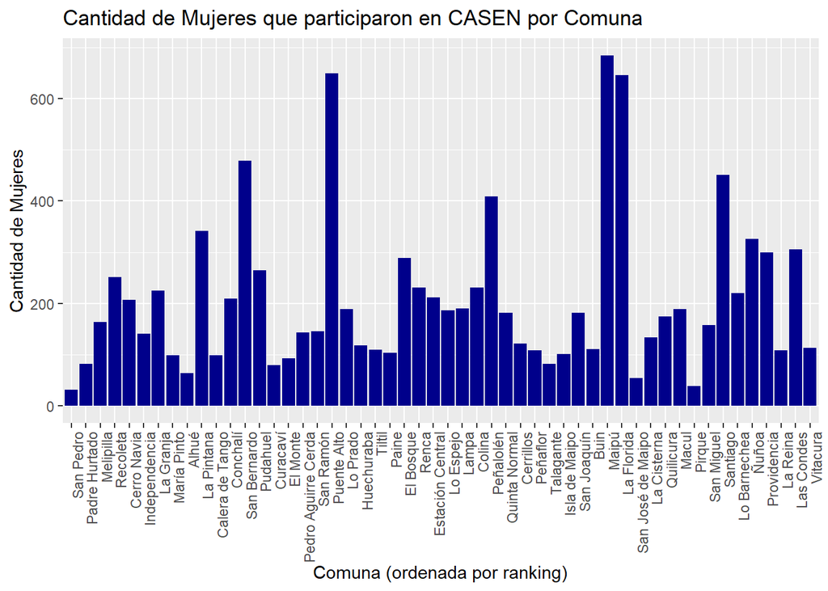

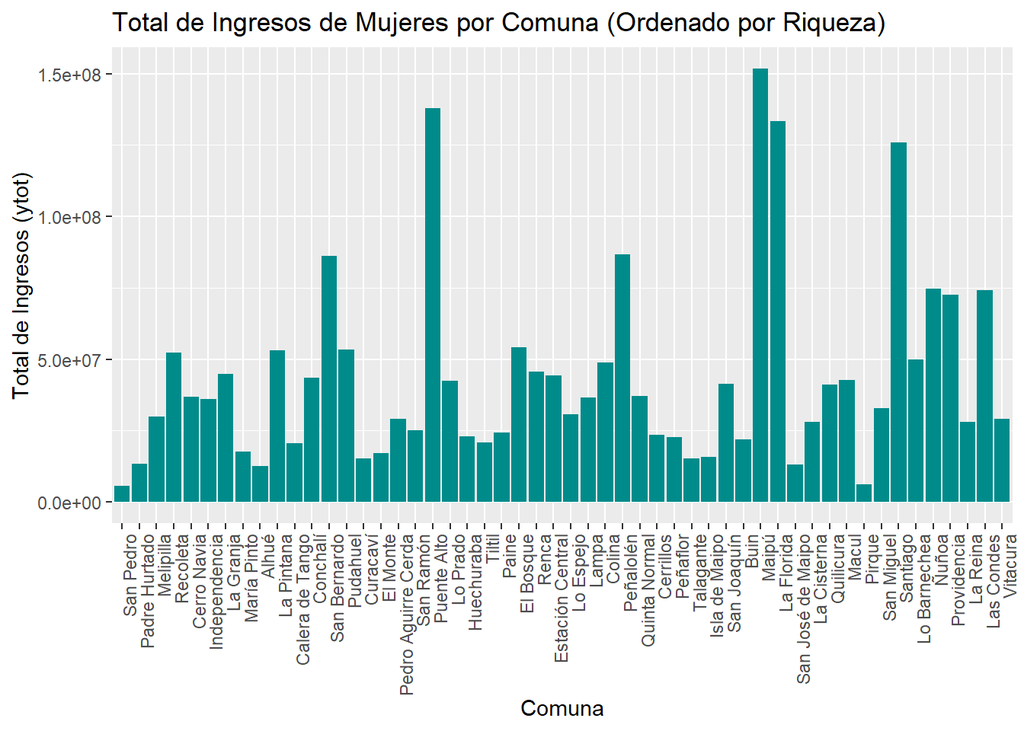

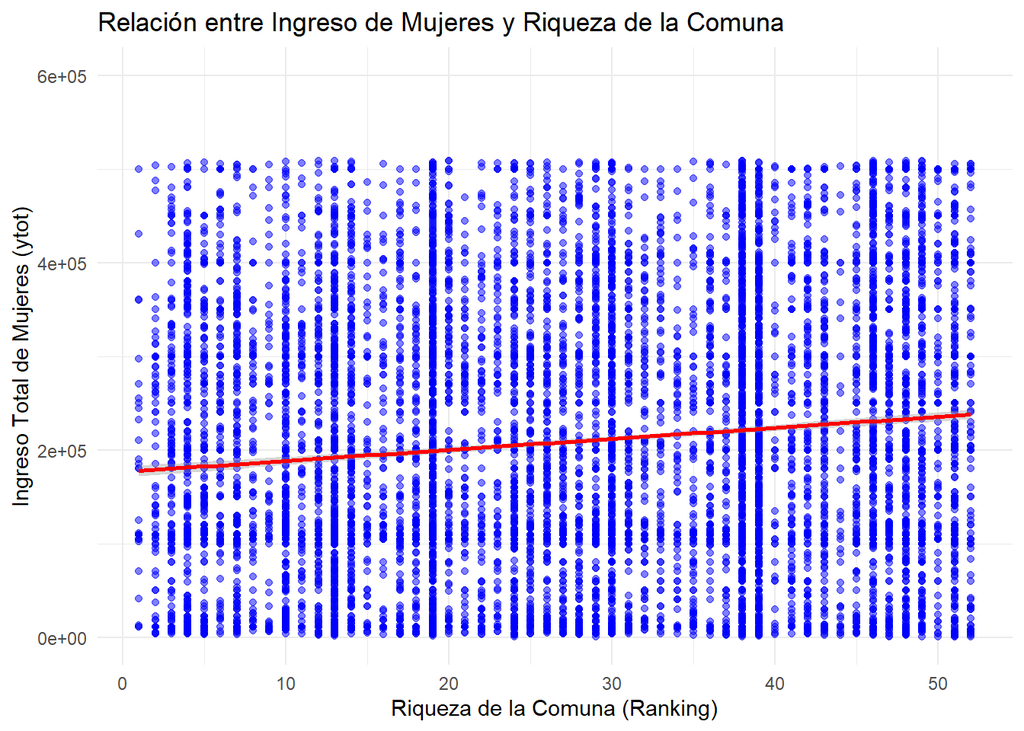

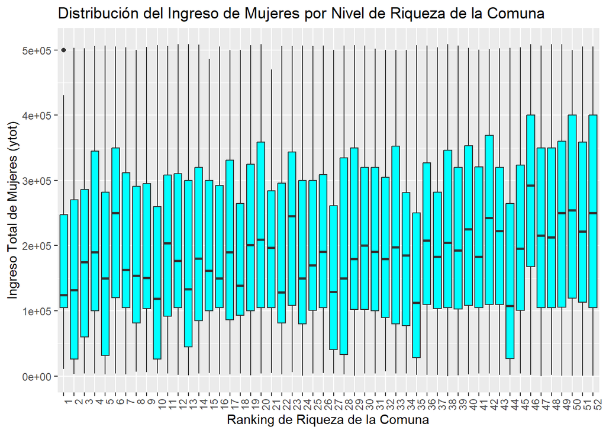

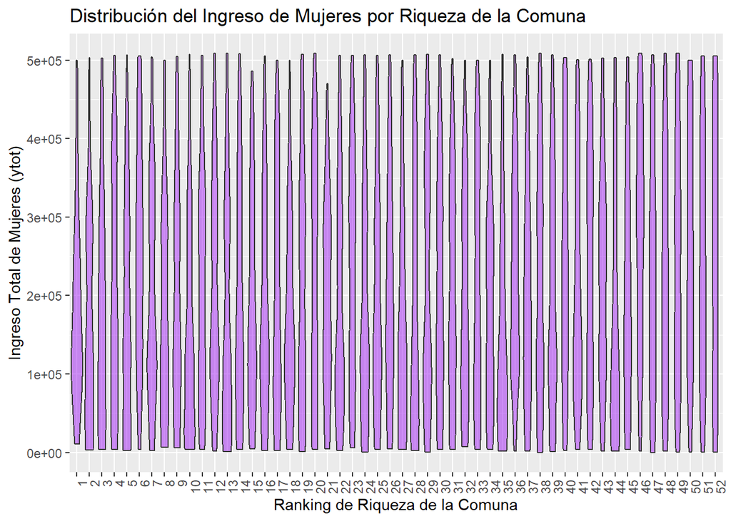

[figure not shown]

[figure not shown]

[figure not shown]

[figure not shown]

[output not shown]

[output not shown]

[figure not shown]

[output not shown]

RESPUESTA A LA PREGUNTA:

[figure not shown]